# Project 2: Modeling, Testing, and Predicting

3. (35 pts) Build a linear regression model predicting one of your response variables from at least 2 other variables, including their interaction. Mean-center any numeric variables involved in the interaction.

Interpret the coefficient estimates (do not discuss significance) (10) Plot the regression using ggplot() using geom_smooth(method=“lm”). If your interaction is numeric by numeric, refer to code in the slides to make the plot or check out the interactions package, which makes this easier. If you have 3 or more predictors, just chose two of them to plot for convenience. (8) Check assumptions of linearity, normality, and homoskedasticity either graphically or using a hypothesis test (4) Regardless, recompute regression results with robust standard errors via coeftest(..., vcov=vcovHC(...)). Discuss significance of results, including any changes from before/after robust SEs if applicable. (8)

```r
library(lmtest)
library(sandwich)
medicaid2 <- mutate(medicaid, access2 = ifelse(access > 0.5, "high", "low"))
fit <- lm(health1~ethnicity*access2, data = medicaid2)
summary(fit)
```

```
##
## Call:
## lm(formula = health1 ~ ethnicity * access2, data =
medicaid2)
##
## Residuals:
## Min 1Q Median 3Q Max
## -2.3189 -1.1209 -0.3399 0.8721 7.1621
##
## Coefficients:
## Estimate Std. Error t value Pr(>|t|)
## (Intercept) -0.05431 0.11358 -0.478 0.633
## ethnicityother -0.22643 0.21619 -1.047 0.295
## access2low 0.10921 0.12957 0.843 0.399
## ethnicityother:access2low 0.15780 0.24307 0.649 0.516
##
## Residual standard error: 1.437 on 992 degrees of freedom
## Multiple R-squared: 0.003371, Adjusted R-squared:
0.0003572
## F-statistic: 1.119 on 3 and 992 DF, p-value: 0.3405
```

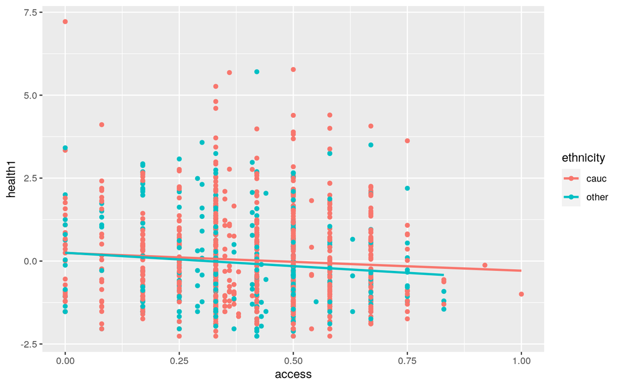

```r
ggplot(medicaid, aes(x = access, y = health1, group = ethnicity)) + geom_point(aes(color = ethnicity)) + geom_smooth(method = "lm", se = F, aes(color = ethnicity))
```

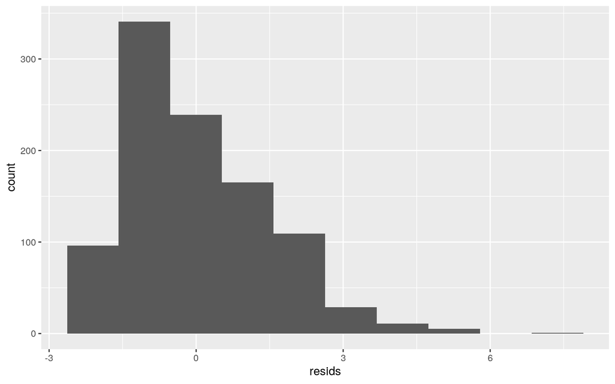

```r
resids<-lm(health1~ethnicity + access2, data=medicaid2)$residuals
fitted<-lm(health1~ethnicity + access2, data=medicaid2)$fitted.values
ggplot()+geom_histogram(aes(resids),bins=10)
```

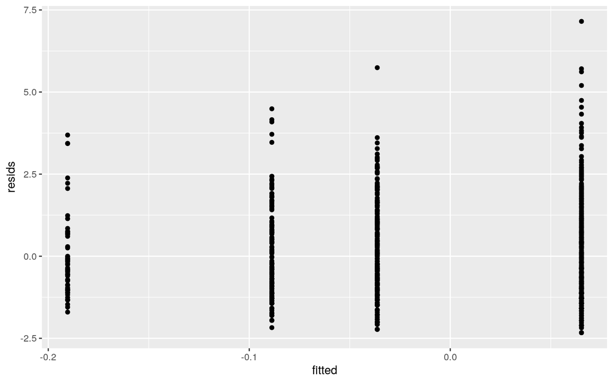

```r
ggplot()+geom_point(aes(fitted,resids))
```